# Ordinal Logistic Regression with the Big Five

Lab demo: does Agreeableness predict ‘Get angry easily’?

## Question and Predictions

The `bfi` data contain 25 personality items from 2,800 people, five items per Big Five trait. Each item is answered on a 6-point scale from *Very inaccurate* to *Very accurate*.

The **chosen trait is Neuroticism**. The ordered outcome is one Neuroticism item, **N1, “Get angry easily.”** The predictor is a person’s **Agreeableness subscale score**, the mean of A1 to A5 with A1 reverse-keyed.

I predict that as people are more agreeable, they will be less likely to get angry easily.

Be sure to check assignment instructions for what should be included in your report. Not all descriptive components are included in this demo.

## Load and inspect the data

# 1. Look at the outcomes first

## The ordered outcome

Check that no category is empty or very sparse.

```
# A tibble: 6 × 3
  N1                        n      p
  <ord>                 <int>  <dbl>
1 Very inaccurate         654 0.235
2 Moderately inaccurate   654 0.235
3 Slightly inaccurate     427 0.154
4 Slightly accurate       515 0.185
5 Moderately accurate     334 0.120
6 Very accurate           194 0.0698
```

Every category has plenty of responses (the smallest, *Very accurate*, has 194), so each threshold can be estimated without collapsing categories.

This can be displayed graphically:

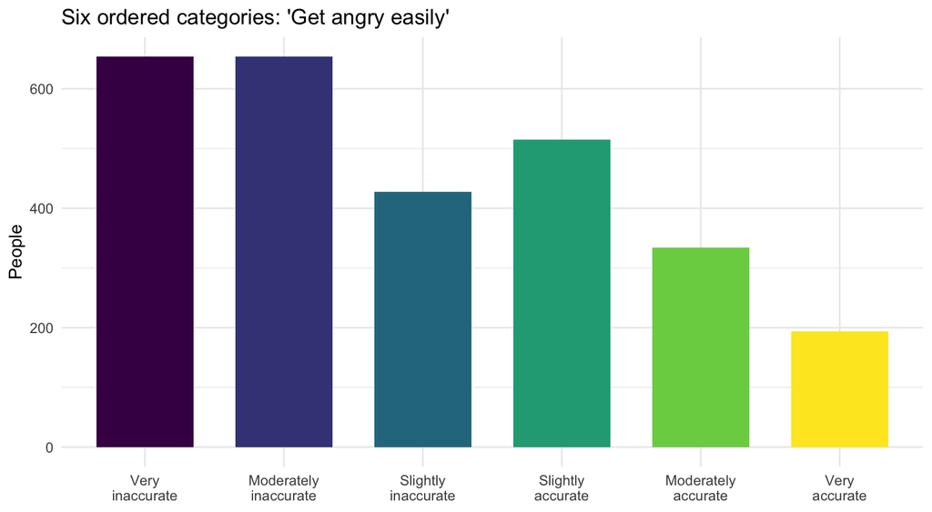

## How the predictor relates to the responses

We can also visualize how the predictor relates to the responses, seeing how each person’s Agreeableness score relates to their N1 response. Because many people have the same Agreeableness score and the same N1 response, we use *`geom_jitter`* to spread out the overlapping points.

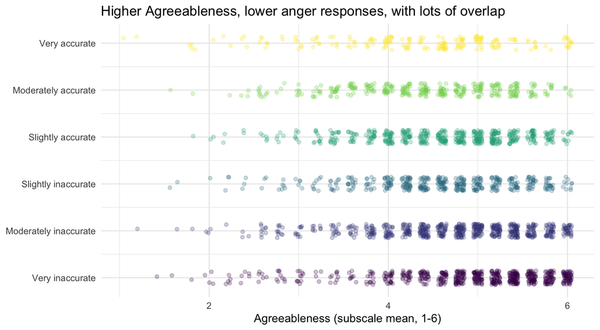

The outcome takes only six values. A good model should predict a probability for each of those six categories, not a specific decimal average that is not an option to choose.

## An unordered outcome

Each person’s **dominant trait** (their highest of the five subscale scores) is a set of categories with **no built-in order**. Being highest on Openness is not “more” than being highest on Agreeableness. An outcome like this requires a baseline-category (multinomial) model, such as `nnet::multinom()`, rather than `clm()`.

Here we can see how many people have each trait as their highest.

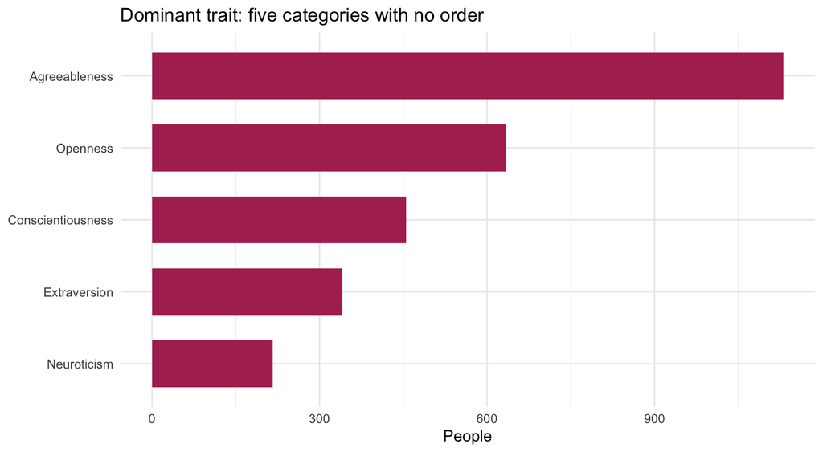

# 2. Cumulative probabilities

A cumulative probability is the probability of responding **with a specific response category (*j*)** or lower. With six categories there are five cumulative probabilities to model. This is because we are dealing with cumulative thresholds which we are converting to probabilities. Remember that cumulative thresholds are cumulative — meaning they capture the probability of a participant providing any response option OR one below it (i.e., selecting slightly inaccurate OR moderately inaccurate OR very inaccurate). That is why we have 5 cumulative probabilities and not six – the cumulative probability of the sixth category (very accurate) is 100%.

| Category in N1 (j) | n | P(Y = j) | P(Y ≤ j) | Odds of ≤ j | Log-odds of ≤ j |
| --- | --- | --- | --- | --- | --- |
| Very inaccurate | 654 | 0.235 | 0.235 | 0.31 | −1.18 |
| Moderately inaccurate | 654 | 0.235 | 0.471 | 0.89 | −0.12 |
| Slightly inaccurate | 427 | 0.154 | 0.625 | 1.66 | 0.51 |
| Slightly accurate | 515 | 0.185 | 0.810 | 4.26 | 1.45 |
| Moderately accurate | 334 | 0.120 | 0.930 | 13.32 | 2.59 |
| Very accurate | 194 | 0.070 | 1.000 | — | — |

Each cumulative probability splits the scale in two, as at or below *j* versus above *j*.This becomes a binary outcome which we can easily model using logit as our link function. The ordinal model does this at every threshold point at once, and the order of the categories is built in.

# 3. The model with a centred predictor

We **centred** Agreeableness earlier, so that the thresholds describe a person of average Agreeableness (4.6558675), rather than an impossible person scoring 0 on a 1-6 scale. Centring changes the thresholds but **not** the slope.

When reading the `summary()` output, the **thresholds** are the points at which a response moved from one category to the next. **Coefficients** are the **slopes** which represent the effect of Agreeableness on the latent logit scale.

```
formula: N1 ~ agree_c
data:    data

 link  threshold nobs logLik   AIC     niter max.grad cond.H
 logit flexible  2778 -4731.24 9474.48 5(0)  1.38e-13 2.2e+01

Coefficients:
        Estimate Std. Error z value Pr(>|z|)
agree_c -0.39757    0.03932  -10.11   <2e-16 ***
---
Signif. codes:  0 '***' 0.001 '**' 0.01 '*' 0.05 '.' 0.1 ' ' 1

Threshold coefficients:
                                          Estimate Std. Error z value
Very inaccurate|Moderately inaccurate     -1.20939    0.04527 -26.713
Moderately inaccurate|Slightly inaccurate -0.11993    0.03841  -3.123
Slightly inaccurate|Slightly accurate      0.52131    0.03959  13.167
Slightly accurate|Moderately accurate      1.48239    0.04889  30.321
Moderately accurate|Very accurate          2.64027    0.07502  35.193
```

```
    Very inaccurate|Moderately inaccurate
                               -1.2093865
Moderately inaccurate|Slightly inaccurate
                               -0.1199271
    Slightly inaccurate|Slightly accurate
                                0.5213096
    Slightly accurate|Moderately accurate
                                1.4823900
        Moderately accurate|Very accurate
                                2.6402711
                                  agree_c
                               -0.3975718
```

The estimated slope is beta = -0.3975718, so Higher Agreeableness **raises** the log-odds of being at or below each threshold, which shifts responses toward the **lower** (“inaccurate”) categories.

## What the centred thresholds mean

| Category | Threshold above category | P(Y ≤ j) | P(Y = j) |
| --- | --- | --- | --- |
| Very inaccurate | −1.21 | 0.23 | 0.23 |
| Moderately inaccurate | −0.12 | 0.47 | 0.24 |
| Slightly inaccurate | 0.52 | 0.63 | 0.16 |
| Slightly accurate | 1.48 | 0.81 | 0.19 |
| Moderately accurate | 2.64 | 0.93 | 0.12 |
| Very accurate | — | 1.00 | 0.07 |

# 4. Null model versus one-predictor model

The null model has thresholds only. With no predictors, its thresholds reproduce the observed cumulative log-odds from Section 2 exactly:

```
    Very inaccurate|Moderately inaccurate
                               -1.1779490
Moderately inaccurate|Slightly inaccurate
                               -0.1167631
    Slightly inaccurate|Slightly accurate
                                0.5089062
    Slightly accurate|Moderately accurate
                                1.4495892
        Moderately accurate|Very accurate
                                2.5892357
```

```
[1] -1.1779490 -0.1167631  0.5089062  1.4495892  2.5892357
```

This is a useful sanity check: it shows the thresholds are just cumulative log-odds. Once a predictor is added, the thresholds become *conditional* on it (here, describing an average-Agreeableness person), so they no longer match the raw proportions.

Now we compare the two nested models with a likelihood ratio test (LRT) and AIC:

```
Likelihood ratio tests of cumulative link models:

         formula:     link: threshold:
null     N1 ~ 1       logit flexible
one_pred N1 ~ agree_c logit flexible

         no.par    AIC  logLik LR.stat df Pr(>Chisq)
null          5 9576.7 -4783.3
one_pred      6 9474.5 -4731.2  104.18  1  < 2.2e-16 ***
---
Signif. codes:  0 '***' 0.001 '**' 0.01 '*' 0.05 '.' 0.1 ' ' 1
```

Adding Agreeableness improves fit substantially.

| Model | Parameters | logLik | AIC | ΔAIC |
| --- | --- | --- | --- | --- |
| Null | 5 | −4,783.3 | 9,576.7 | 102.2 |
| Agreeableness | 6 | −4,731.2 | 9,474.5 | 0.0 |

AIC agrees with the likelihood ratio test: the Agreeableness model is preferred by a wide margin (ΔAIC = 102.2).

## 4b. Comparing and interpreting the chosen model

The slope, beta = -0.3975718, is on the latent logit scale. A one-point increase in Agreeableness moves a person’s latent “anger proneness” as reflected by N1 down by 0.3975718. The middle categories are each about 0.8011586 units wide on that scale, so one point of Agreeableness shifts someone by roughly 49.6246064% of a category.

# 5. Checking proportional odds

The model assumes one shared slope across all five threshold `nominal_test()` refits the model with a separate Agreeableness slope at each threshold and compares the two models with an LRT.

`nominal_test()` checks it by fitting a second model in which Agreeableness gets a separate slope at each threshold: a different push at each gap. A likelihood ratio test then compares the two models. If giving Agreeableness five pushes doesn’t fit significantly better than one, the shared slope is enough and the proportional odds assumption holds.

```
Tests of nominal effects

formula: N1 ~ agree_c
        Df  logLik    AIC    LRT Pr(>Chi)
<none>     -4731.2 9474.5
agree_c  4 -4728.4 9476.7 5.7443   0.2191
```

The test is **not** significant. The data are consistent with a single shared slope, so the proportional-odds model is retained.

If this test was significant, we should use a partial proportional-odds model as seen below, and report this alongside the main model.

```
    Very inaccurate|Moderately inaccurate.(Intercept)
                                           -1.2171717
Moderately inaccurate|Slightly inaccurate.(Intercept)
                                           -0.1224217
    Slightly inaccurate|Slightly accurate.(Intercept)
                                            0.5177165
    Slightly accurate|Moderately accurate.(Intercept)
                                            1.4904818
        Moderately accurate|Very accurate.(Intercept)
                                            2.6511598
        Very inaccurate|Moderately inaccurate.agree_c
                                            0.4312772
    Moderately inaccurate|Slightly inaccurate.agree_c
                                            0.3888038
        Slightly inaccurate|Slightly accurate.agree_c
                                            0.3416494
        Slightly accurate|Moderately accurate.agree_c
                                            0.4282197
            Moderately accurate|Very accurate.agree_c
                                            0.4330341
```

If our model required nominal effects, we would report the threshold-specific odds ratios and their confidence intervals.

# 6. Interpreting the coefficient by changing odds ratios to probabilities

**Agreeableness:** e^beta = 0.6719497, 95% CI [0.6219819, 0.7256508], p 4.9492499^{-24}. Each one-point increase in Agreeableness multiplies the odds of responding **above any threshold** (for example, “Slightly accurate or higher” versus lower) by 0.6719497. That is a **33% decrease** in those odds.

An odds ratio is not a change in the number of categories, and it is not a ratio of probabilities. The table below translates it into probabilities. It uses the threshold between *Slightly inaccurate* and *Slightly accurate*, so it shows the probability of endorsing the item at all:

| Agreeableness | P(Slightly accurate or higher) | Odds |
| --- | --- | --- |
| 3 | 0.53 | 1.15 |
| 4 | 0.44 | 0.77 |
| 5 | 0.34 | 0.52 |
| 6 | 0.26 | 0.35 |

Each one-point step multiplies the odds by 0.6719497, which is the OR. The **probability**, however, falls by 0.0989734 from 3 to 4 but by only 0.0830282 from 5 to 6. A constant odds ratio implies different probability changes depending on where you start, which is why we also plot predicted probabilities.

# 7. Predicted probabilities and odds ratios

## 7a. Predicted category probabilities

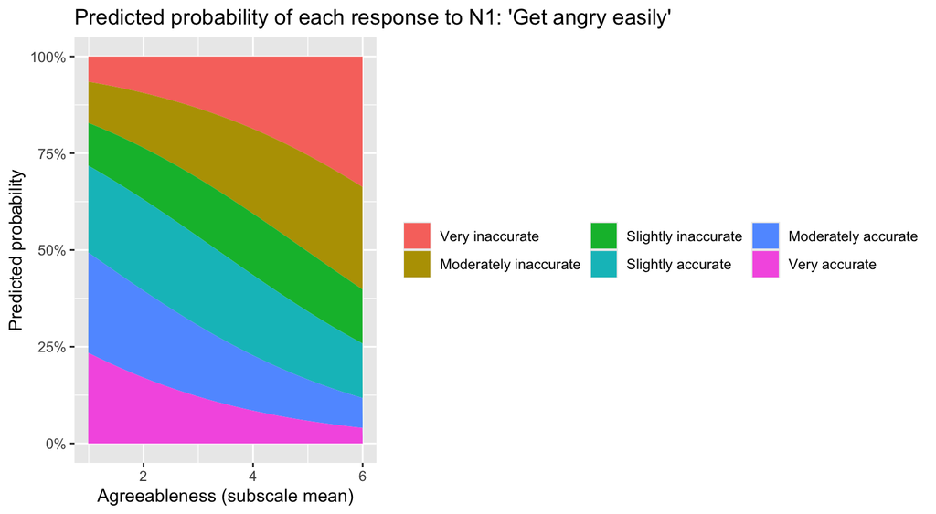

At low Agreeableness, much of the probability sits in the “accurate” categories. As Agreeableness rises, it moves toward *Very inaccurate* and *Moderately inaccurate*. At every value of Agreeableness, the six probabilities sum to 1, which is why the stack always reaches 100%.

## 7b. Coefficient plot of cumulative odds ratios

The plot shows the shared proportional-odds OR alongside the threshold-specific ORs from Section 5, so it also works as a visual check of proportional odds.

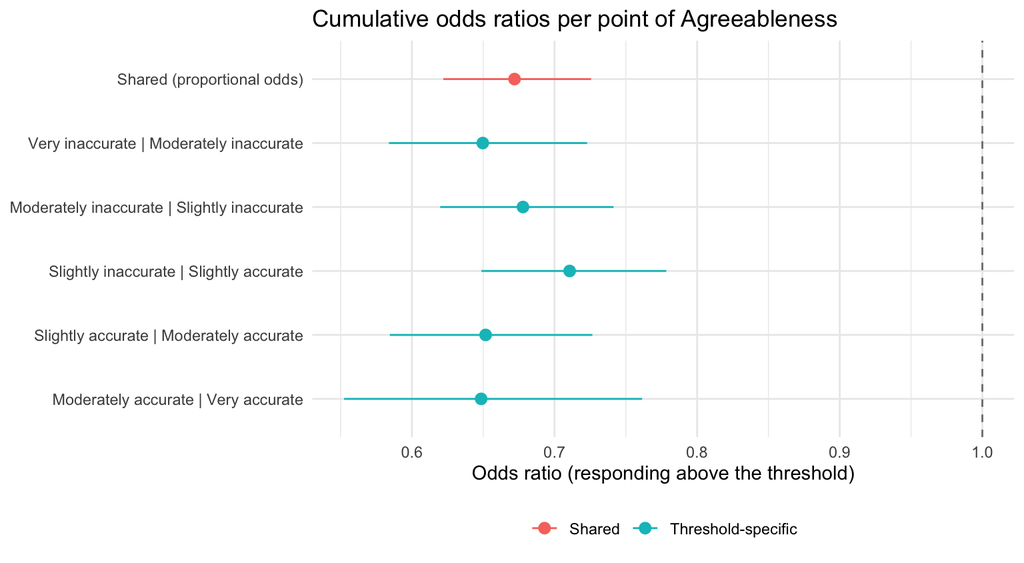

Every interval sits well below 1 (the dashed line). The threshold-specific estimates also cluster around the shared estimate, which is what proportional odds implies.

# 8. Results paragraph

We fit a cumulative logit (proportional-odds) model predicting responses to “Get angry easily” from mean-centred Agreeableness (N= 2,778). Agreeableness improved fit over a null model, chi^2(1) = 104.1800071, p 1.8474542^{-24}. As predicted, more agreeable people were less likely to endorse the item, OR = 0.6719497, 95% CI [0.6219819, 0.7256508]: each one-point increase in Agreeableness lowered the odds of a higher response by about 33%. The proportional-odds assumption held, chi^2(4) = 5.7443056, p 0.2190748. The predicted probability of endorsing the item fell from 0.5342007 at an Agreeableness score of 3 to 0.2581323 at a score of 6 (Figure X).